# Analysis for Paper 1 on MD Wellbeing

#### Background

This is an initial demonstration of the ‘archetypes’ approach outlined in the paper one working document here: https://docs.google.com/document/d/1WtGs5gIlHPSU5NlpwfHgpyqfdgvCzZD40f9xD5dRaRg/edit?usp=sharing

Our (revised) draft RQs (to be further discussed) for this paper are:

1. How are different livelihood strategies associated with different configurations of multidimensional human wellbeing at the household level across our sites?
2. Within this, which configurations of wellbeing outcomes are associated with livelihoods that include harvests from local uncultivated ecosystems?
3. How does the prevalence of these different sets of livelihood-wellbeing relationships change with social structure, local ecological productivity and access to external markets?

There are two main ideas behind the proposed multivariate archetypes approach: 1) to allow us to synthesise and compare between different datasets with different variables and contexts; and 2) to allow us to focus on nature-wellbeing *relationships* as dependent variables, rather than having only nature/livelihoods or wellbeing as dependent variables. Given data limitations, we are focusing on material contributions of harvests from nature (i.e. a subset of provisioning services). We are also using a livelihood framing to place contributions from nature alongside contributions from elsewhere. For wellbeing, we are aiming to keep it as multidimensional as possible (i.e. by not using aggregate indices).

In this archetypes approach we therefore distinguish between two classes of causal mechanisms: 1) within-household mechanisms between different sources of livelihoods and dimensions of wellbeing; and 2) contextual causal mechanisms which result in particular sets of these household-level livelihood-wellbeing relationships. We want to know how class 2 mechanisms cause class 1 mechanisms to vary (see Figure 1 in doc linked above).

The archetypes approach helps us to represent in a simplified way sets of class 1 mechanisms, so that we can focus on how class 2 mechanisms predict these.

In this methodology we set expectations from theory of the class 1 (livelihood-wellbeing) mechanisms we expect to see, and represent these through household-level ‘livelihood-wellbeing archetypes’, defined by household-level associations between wellbeing and livelihood variables (e.g. modernisation theory might expect professionalised livelihoods to co-occur with higher material wellbeing; safety net theory might expect livelihoods from CPR to prevent (i.e not co-occur with) the worst material wellbeing outcomes). We can then assess class 2 mechanisms by testing under which contextual conditions different livelihood-wellbeing archetypes are more prevalent.

We can run the analysis through both inductive and deductive approaches. Below I demonstrate the inductive approach because for the most part it uses established clustering and ordination methods from community ecology. We can adapt this to a deductive approach (e.g. by testing the prevalence of dummy households representing hypothesised archetypes), but to my knowledge this has not been done elsewhere.

All variables and aspects of the methods need to be finalised… so the approach and results here are just illustrative!

#### Inductive approach

**Generating archetypes**

For the inductive approach, we can use clustering techniques to generate archetypes from the data. The resulting archetypes represent groups of households with similar associations between all livelihood and wellbeing variables.

Below are household livelihood-wellbeing archetypes generated through heirarchical agglomerative clustering using gower dissimilarity (good for mixed data types) and complete aggregation. The number of clusters is based on the majority rule across 30 indices (using NbClust algorithm). Final choice of dissimilarity, aggregation and clustering methods TBD.

First is the dendrogram, showing how households (at the bottom of the tree) are grouped into increasingly generalised groups or clusters based on the similarity of the within-household associations between variables. In this case, we have decided to use four clusters (each grouped in a red box).

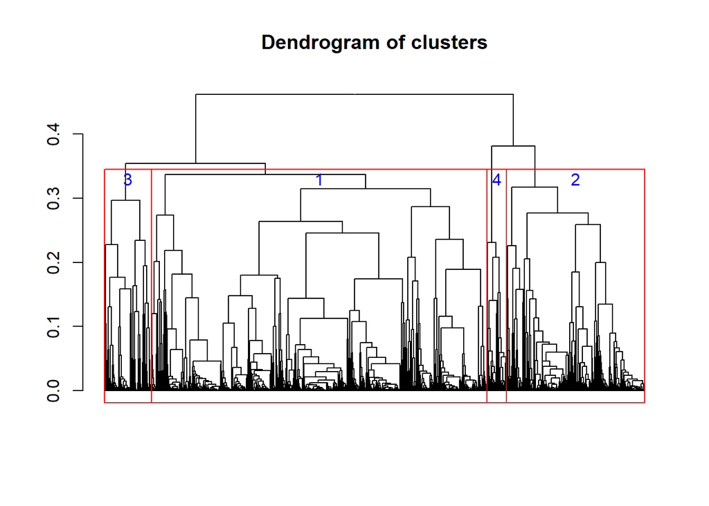

Next is a table showing the importance of different household-level variables for describing each of the ‘archetypes’. See here for a description of the variables: https://docs.google.com/document/d/1WtGs5gIlHPSU5NlpwfHgpyqfdgvCzZD40f9xD5dRaRg/edit#bookmark=id.253qsmxjfqul Values are mean values for that archetype (we need to think if this is the best way to describe archetypes e.g. or median? weighted average? graphical - e.g. radar chart?). Livelihood values are absolute annual figures in the local currency (’000s of Bangladeshi taka), while wellbeing outcomes are 1 to 100 (means of binary variables). Variables with an asterisk are ranked as having higher importance for defining the clusters (in top 50% of variables, with variable importance assessed through mean decrease in accuracy method using random forests) - i.e. it is where most of the difference is, even if the values are lower compared to other variables.

Underneath the table I provide a ‘narrative synthesis’ of these archetypes to help with synthesis and links to theory.

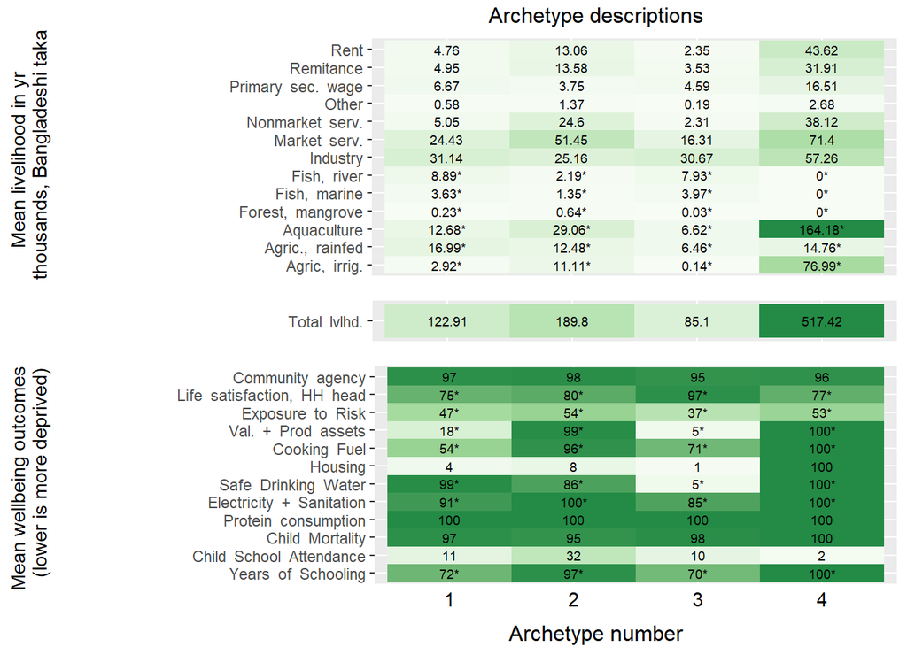

```
## [1] "Households in cluster"
```

```
##
##   1   2   3   4
## 981 403 137  57
```

*Archetype synthesis*

Within all archetypes, on average a large amount of livelihood is coming from the service and industry sectors (all archetypes also look quite diverse, but this is an artifact of the clustering and using mean values - we could include livelihood diversity as a seperate metric). All archetypes are also not greatly deprived in community agency, electricity, sanitation, child mortality and protein. The variable importance values show that archetype membership is mainly determined by differences in livelihoods from sources of cultivated and uncultivated nature, and variation in wellbeing outcomes. Some archetypes are also generating much more livelihood from intensive cultivation and services sectors, and from rents and remittances.

Here is an attempt to synthesise the archetypes (partly drawing on langauge from Dorward et al. rural livelihood typologies for now: https://drive.google.com/open?id=1n9BywFFYvZisDwhcPvTTEgLFuhINnAz9).

1. ‘Hanging in’ through wild harvests, housing poor, moderately satisfied
2. ‘Stepping out’ through services, housing poor, moderately satisfied
3. ‘Dropping out’ with wild harvests, asset, housing and water poor, high satisfaction
4. ‘Stepping up and out’ through intensification and services, not materially deprived, moderately satsified

Broadly these align with what we would expect from theories on rural livelihoods, with poorer households more reliant on uncultivated nature, and smaller (elite?) groups dominating intensive cultivation and the service sectors. Interesting that the HH with the lowest material WB have reported the highest life satisfaction. The commonalities suggest that public infrastructure and services are meeting many of the basic needs of most people (although there are no doubt outliers or further subsets of households where these are not met), and perhaps that protein is widely available (as far as we are measuring it… perhaps because of good market connectivity? See next section).

**Assessing contextual factors**

We can then use these archetypes to generate fuzzy membership scores for each household on the degree to which a household is represented by each archetype. We can then use these to assess the prevalence of different archetypes under different conditions. Here we use gower distance and non-metric dimensional scaling (which is robust to different data types and distributions) to generate membership scores across 3 dimensions (ordination would not converge with only 2 dimensions).

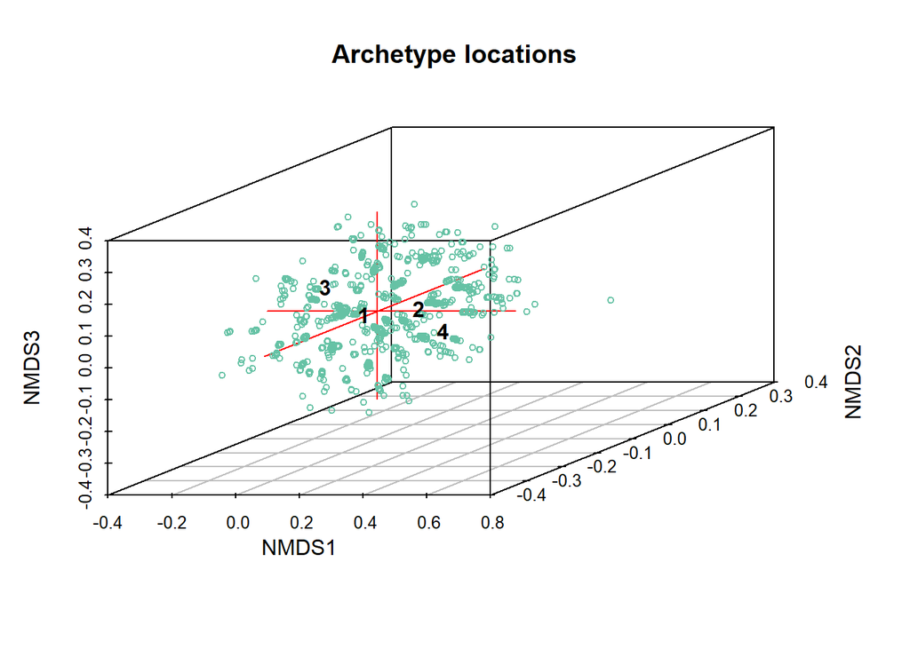

We can then take these scores and put them in a regression to test hypotheses on how contextual factors affect the prevelance of different livelihood-wellbeing archetypes, and within that the role of (uncultivated) nature.

You can also assess the gradients of contextual variables in a more qualitative way by plotting them directly on an ordination plot like the one above, but it gets quite messy… particularly in 3 dimensions!

Before we can put too much faith in results, we need to finalise contextual variables and exact methods (e.g. deciding clustering and regression methods; if/how to use NMDS scores as response variables; thinking about spatial congruence of settlement level variables; assessing spatial autocorrelation). But as an example, below are coefficient plots from a linear mixed model for each archetype, with settlement as a random effect. The dependent variable in each is the distance of each household from the cluster (i.e. archetype) centroid (i.e. the sum of the root squares of distances from the centroid across all 3 dimensions). Model fits all looks ok (residuals fairly normally distributed and homoscedastic).

In relation to the broad types of hypotheses we have been talking about:

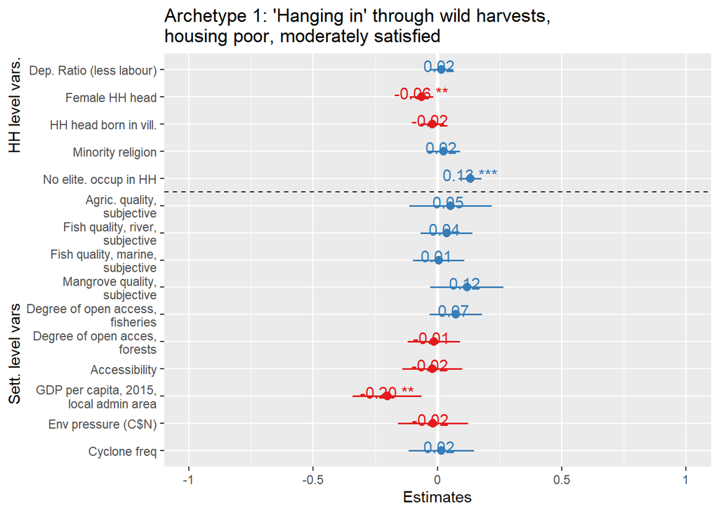

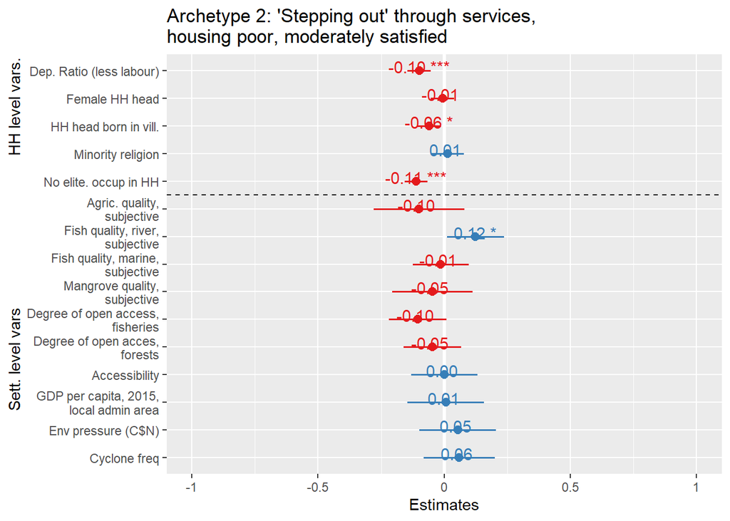

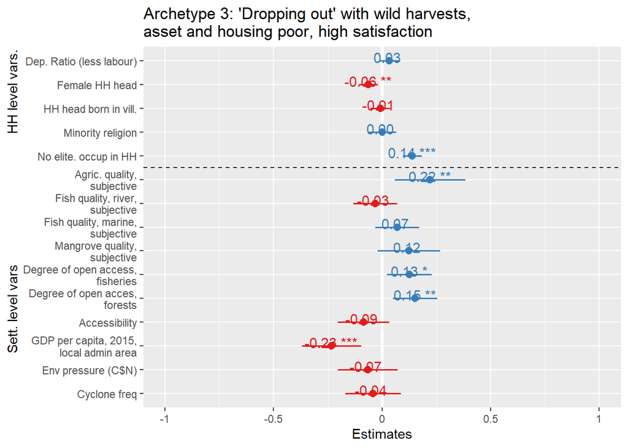

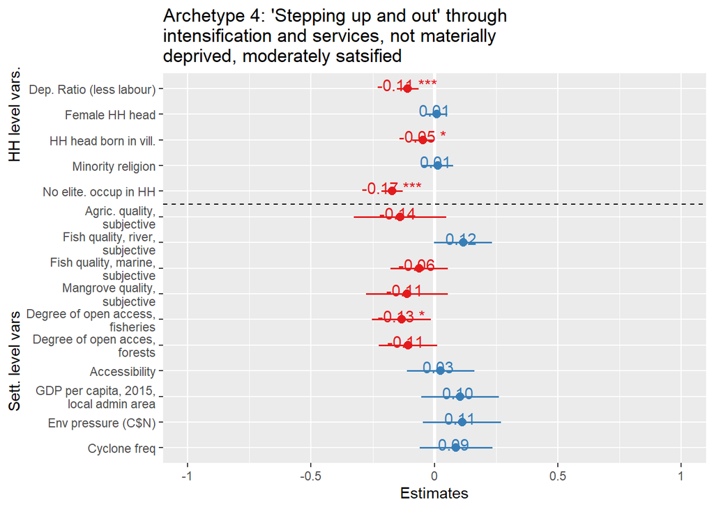

We can also map the occurence of different archetypes spatially to help visualise variation between settlements, and associated differences in context. Below is a snap shot of nine settlements (Mouzas) from coastal areas of the DELTAS dataset. The size of each point is the prevalence of that archetype in the village. All archetypes are present in each village with what looks like more variation in archetypes 1 and 4 (and this is true for all settlements, just difficuly to fit on this plot clearly). We can figure out a better way of plotting this, as differences in this map are a little hard to see!

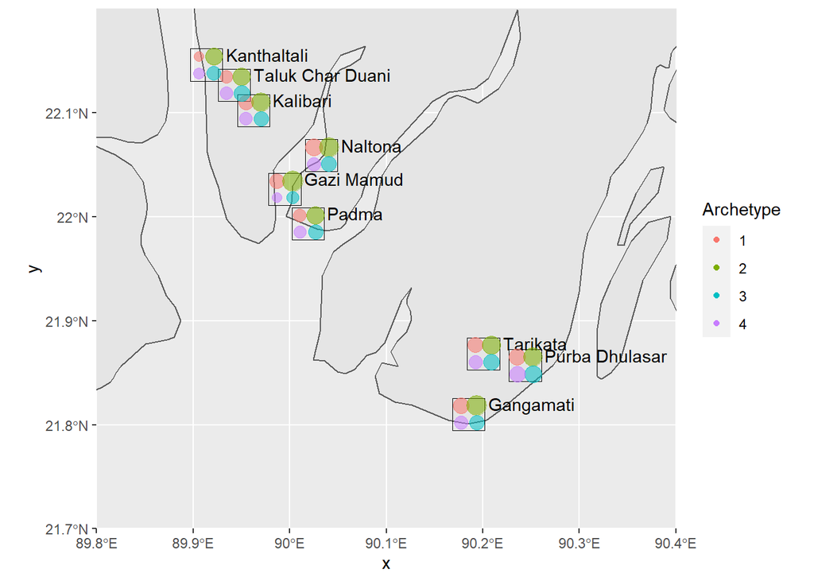

**Summary**

In relation to our RQs (and keeping in mind that these are not final results!):

*1. How are different household livelihood strategies associated with different configurations of multidimensional human wellbeing across our sites?*

As discused under the archetype generation section, households more engaged in intensification and services are associated with higher material wellbeing, but associations with life satisfaction appear less related to livelihood and material wellbeing variables. Aspects of relational wellbeing do not appear to vary across archetypes in this dataset.

*2. Within this, which configurations of wellbeing outcomes are associated with livelihoods with a high proportion of harvests from local uncultivated ecosystems?*

Households more reliant on uncultivated nature generally have lower material wellbeing, but some have higher life satisfaction. There are differences in WB outcomes between different ‘wild harvest’ archetypes, possibly because of tenure (see below).

*3. How does the prevalence of these different sets of livelihood-wellbeing relationships change with social structure, local ecological productivity and access to external markets?*

Re. social structure, more access to labour and engagement in elite occupations mean less reliance on wild harvests and higher material wellbeing outcomes (but not necesarrily life satisfaction). We cannot assess the effect of ecological productivity at this point. Broad differences in local GDP per capita imply less reliance on uncultivated nature and higher material WB.

Within wild harvest archetypes, differences in the type of open access may explain different WB outcomes (to be checked). To further understand how wild harvest livelihoods are associated with different configurations of wellbeing, we could look at drilling down to look at differences amongst households that are reliant on wild harvests (e.g. a further clustering of wild harvest households). Also if we find a reliable clustering solution with a higher number of clusters, we would presumably see more ‘wild harvest’ (and other) archetypes and so could better investigate the differences between them.

We also need to think about how to compare these types of results between datasets. e.g. thematic analysis, QCA?.